# Leveraging Python and JAX in R workflows

Andrés Cruz (UT Austin)

NU Statistical Computing Workshop

Apr 22, 2026

## Python won

- (in ML/AI)
- Are we missing out?

## R vs Python

- **R**: statistics/data analysis focused
  - Data wrangling
  - Plotting
  - Solid stats / econometrics / pol. methodology
- **Python**: general-purpose
  - Inter-operability (e.g., API calls)
  - Cutting-edge AI/ML
- *Question: are LLMs better at R or Python?*

## R vs Python: LLM performance

- 🐍 “LLMs Love Python” (Twist et al. 2026)
  - In language-agnostic queries, “Python accounts for 90-97% of generated solutions” (7)
- ®️ AutoCodeBench performance (Chou et al. 2025, 6)

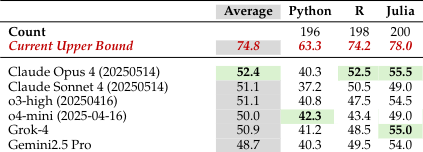

## A compromise

- Integrate tidbits of Python into our R workflows
- Use the [`reticulate`](https://rstudio.github.io/reticulate/) R package
  - Since [Feb 2025](https://posit.co/blog/reticulate-1-41/): `uv` Renaissance
  - Used by ~350 other packages (e.g., [`marginaleffects`](https://marginaleffects.com/bonus/performance.html#solution-b-automatic-differentiation))

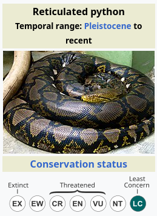

[Source: Wikipedia](https://en.wikipedia.org/wiki/Reticulated_python)

## What we’ll cover today

1. Using Python from R
   - Intro to `reticulate`
   - Example: sentence-level semantic similarity
2. Leveraging JAX, a high-performance Python library
   - Automatic differentiation
   - Example: sensitivity analysis for error propagation

## 1. Using Python from R

## `reticulate`

- A package to interact with Python from R
  - Manages Python packages and environments
  - Translates between R and Python objects
- **Everything happens in R. You write R code!**
  - e.g., (1) R data prep; (2) Python snippet; (3) R analysis

[figure not shown]

## What’s (usually) better in Python?

- Commercial APIs
  - LLMs (Anthropic, OpenAI, Google)
  - OCR (Mistral)
  - Data download (Youtube, Google Maps)
- Pre-trained models for image/video/text
- Cutting-edge scientific computing

## Example: embeddings

- Working with image/video/text usually involves:
  1. Wrangling
  2. Numerical representation
  3. Analysis (stats, plots, etc.)
- For step 2, we often want to use pre-trained encoder models to generate “embeddings”
  - Wide availability in Python, both closed- and open-source

[figure not shown]

[Source: Wikimedia Commons](https://commons.wikimedia.org/wiki/File:Word_embedding_illustration.svg)

## Constitutional consultation (Cruz et al. 2023)

- ~250k citizen submissions to the CL constitutional process
- Compare submissions with topics and text from the world’s constitutions
  1. Wrangle data
  2. Embed text using [multilanguage encoder](https://huggingface.co/intfloat/multilingual-e5-base)
  3. Compute “semantic” similarities

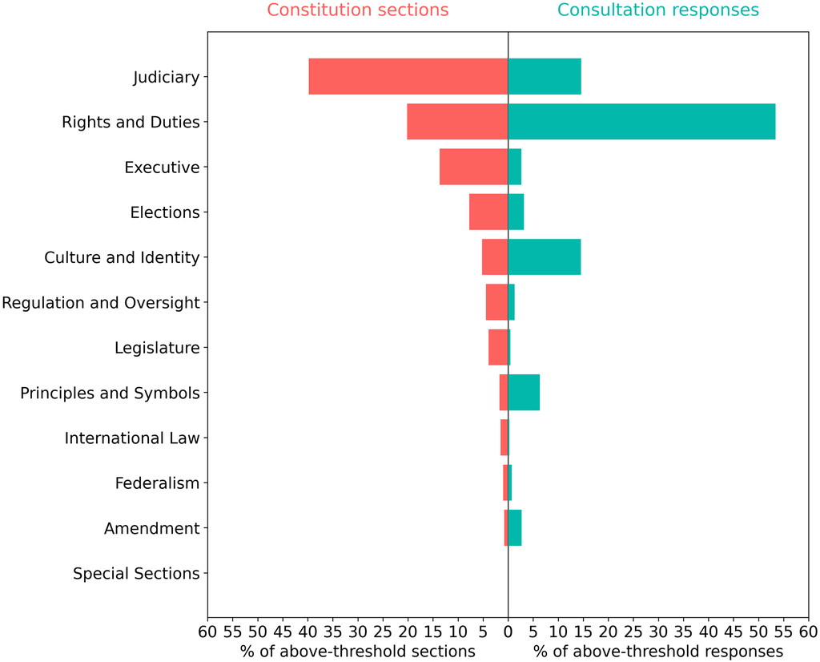

## Script: `1_embeddings.R`

## Translating Python to `reticulate`

- The package automatically handles loops, indexing, and other tricky parts
- R lists do a lot: e.g., `package.module.function()` becomes `package$model$function()`
- In my experience, LLMs are good for short Python-to-`reticulate` translations
  - except for infrastructure (setting, exit)

## 2. Leveraging JAX from R

## [JAX](https://docs.jax.dev/en/latest/)

- A high-performance Python package/ecosystem
- By Google: powers some of their ML/AI
- Good CPU and GPU performance
- Key features:
  - Just-in-time-compilation
  - Automatic vectorization
  - **Automatic differentiation**

[figure not shown]

## How to calculate derivatives?

- Analytic differentiation
  - e.g., we know $f(x)=x^2; f'(x)=2x$.
- Numeric differentiation
  - Approximate derivative by guessing, guessing, guessing…
- Automatic differentiation
  - Under the hood: boil functions down to their elementary operations; use the chain rule.
  - In JAX: differentiate (pretty much) arbitrary functions, e.g., most things in `numpy` (ex: [`marginaleffects`](https://marginaleffects.com/man/r/autodiff.html)).

## Script: `2_jax.R` (part one)

## Example: sensitivity analysis

- Examine the degree to which our assumptions affect our results
- Often apply extreme pressure
  - e.g., how strong would an unobserved confounder need to be to “wipe out” a coefficient of interest? (Cinelli and Hazlett 2020; VanderWeele and Ding 2017)
- Tools: differentiation, optimization

## A sensitivity approach to measurement error

- How much measurement error would invalidate a downstream estimate?

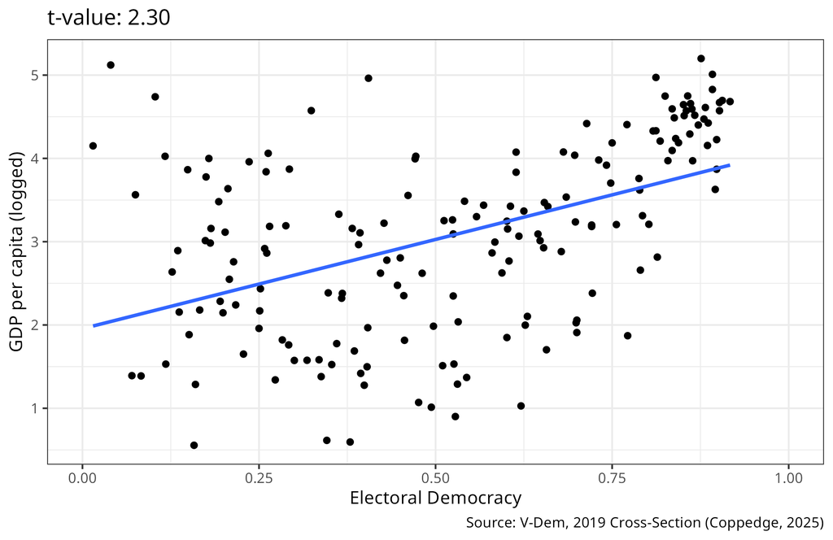

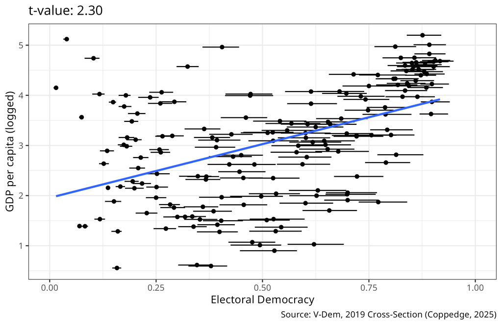

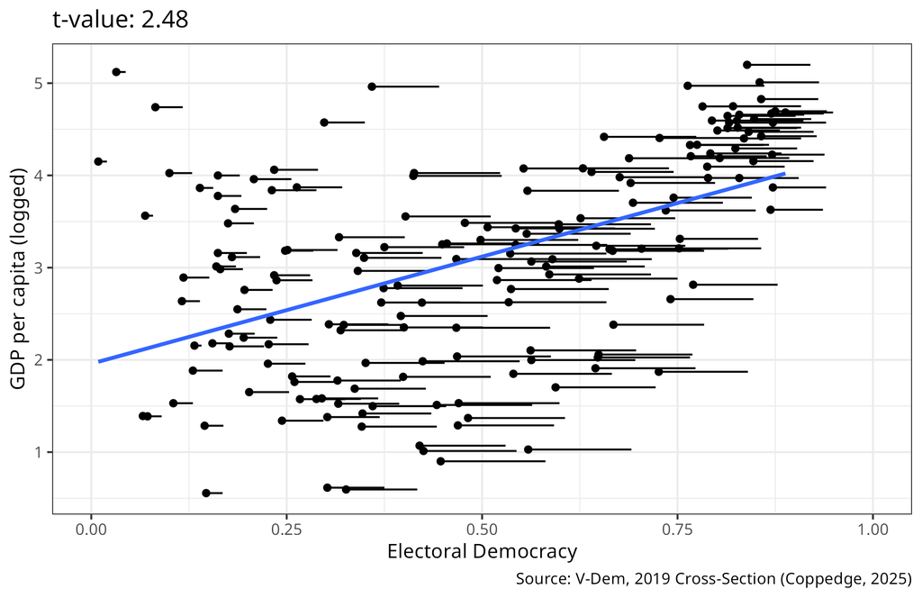

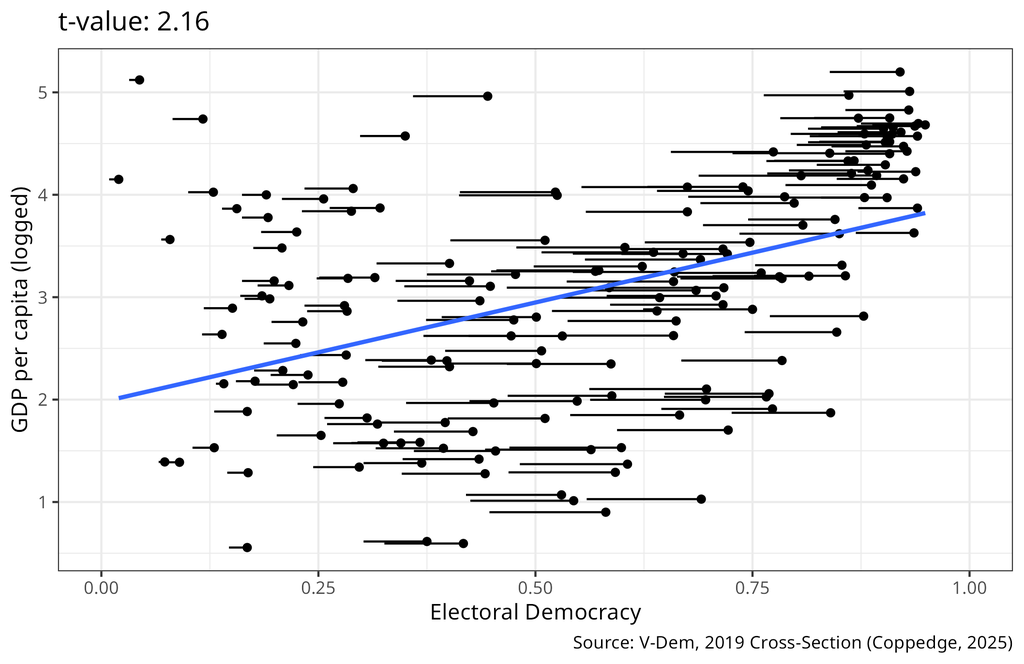

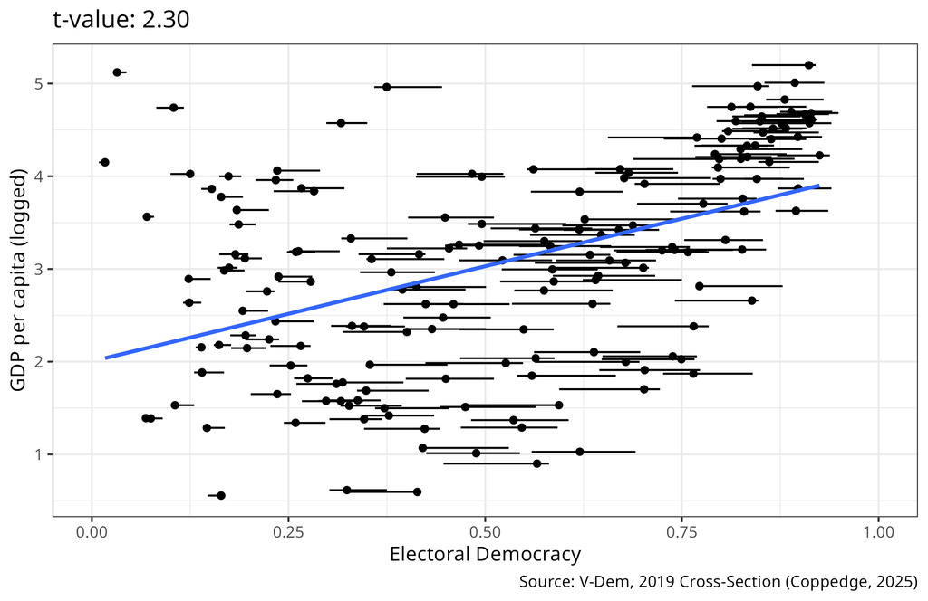

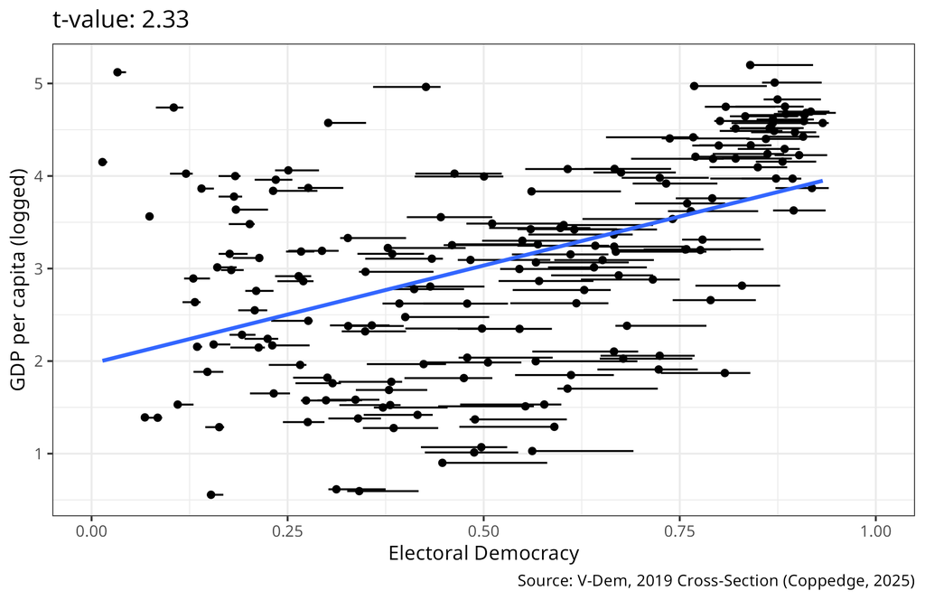

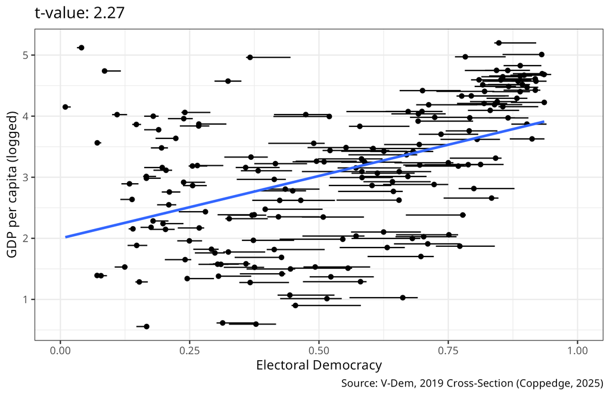

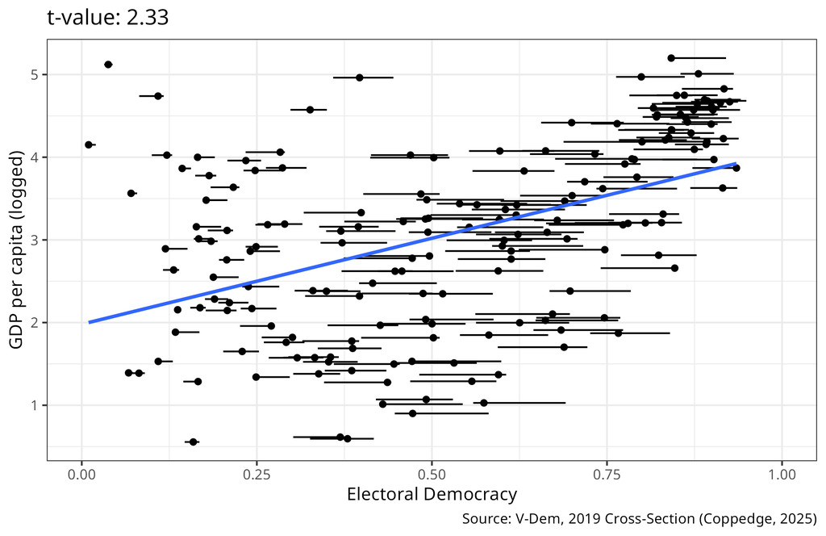

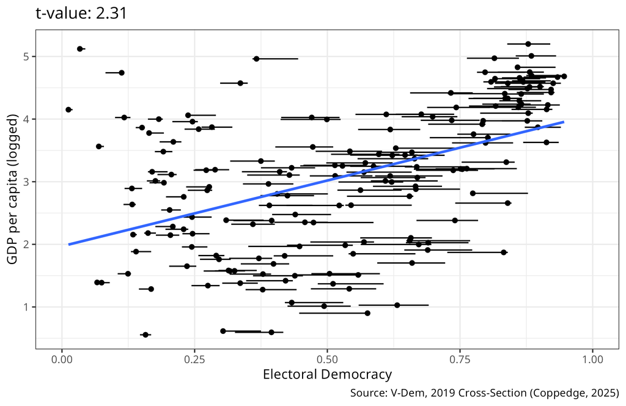

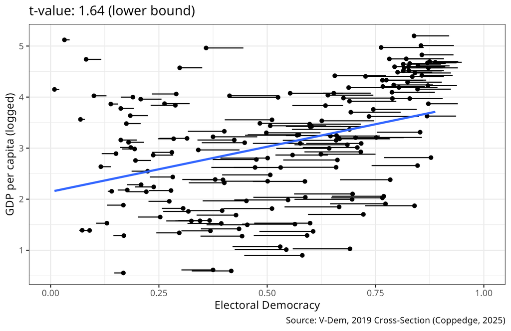

## A constrained optimization problem

- Minimize the quantity of interest, *while respecting the pointwise error ranges*
- We have great algorithms for box-constrained optimization, e.g., L-BFGS-B (Byrd et al. 1995)
- They require derivatives
  - Analytical differentiation is not always available (e.g., MLE)
  - Numerical differentiation is slow and prone to error
- Solution: automatic differentiation!

## Script: `2_jax.R` (part two)

## Summary

- We can integrate Python tidbits into R via `reticulate`
- Good candidates for Python snippets: commercial APIs, pre-trained models, scientific computing
- LLM translation often works, but infrastructure is an always-moving target

## References

Byrd, Richard H., Peihuang Lu, Jorge Nocedal, and Ciyou Zhu. 1995. “A Limited Memory Algorithm for Bound Constrained Optimization.” *SIAM Journal on Scientific Computing* 16 (5): 1190–1208. https://doi.org/10.1137/0916069.

Chou, Jason, Ao Liu, Yuchi Deng, Zhiying Zeng, Tao Zhang, Haotian Zhu, Jianwei Cai, et al. 2025. “AutoCodeBench: Large Language Models Are Automatic Code Benchmark Generators.” https://arxiv.org/abs/2508.09101.

Cinelli, Carlos, and Chad Hazlett. 2020. “Making Sense of Sensitivity: Extending Omitted Variable Bias.” *Journal of the Royal Statistical Society Series B: Statistical Methodology* 82 (1): 39–67. https://doi.org/10.1111/rssb.12348.

Coppedge, Michael, John Gerring, Carl Henrik Knutsen, Staffan I. Lindberg, Jan Teorell, David Altman, Fabio Angiolillo, et al. 2025. “V-Dem Dataset V15.” Varieties of Democracy (V-Dem) Project. https://doi.org/10.23696/vdemds25.

Cruz, Andrés, Zachary Elkins, Roy Gardner, Matthew Martin, and Ashley Moran. 2023. “Measuring Constitutional Preferences: A New Method for Analyzing Public Consultation Data.” *PLOS ONE* 18 (12): e0295396. https://doi.org/10.1371/journal.pone.0295396.

Twist, Lukas, Jie M. Zhang, Mark Harman, Don Syme, Joost Noppen, Helen Yannakoudakis, and Detlef Nauck. 2026. “A Study of LLMs’ Preferences for Libraries and Programming Languages.” https://arxiv.org/abs/2503.17181.

VanderWeele, Tyler J., and Peng Ding. 2017. “Sensitivity Analysis in Observational Research: Introducing the e-Value.” *Annals of Internal Medicine* 167 (4): 268–74. https://doi.org/10.7326/m16-2607.